# Classifying Transcripts using getminipackage

Zhenzhen Wang and Biniam Feleke

05/03/2019

Abstract

The purpose of this mini package is to class both coding and noncoding transcripts into biotypes using the most recent GENCODE annotations. This tool can also be used to define potential lncRNAs, given an available genome transcriptome assembly (a gtf file) or any genomic loci of interest. Any long transcripts that cover more than two coding regions of a genome can be identified using this package.Mini-package version: 1.0

##### References

#### **Genomic data source**

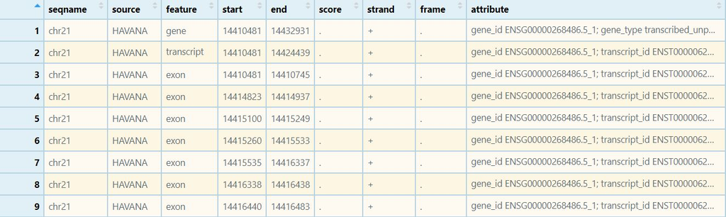

Chromosome 21 of human GRCh37 gtf

GoTop

##### **Extracting summary of genomic data**

There are two way to get genome biotypes: a) “transctipt_type” b) “gene_type”. We used the “transcript_type” to extract the regions of interest using python as shown below. **Note** that the *“PATH_FILE”* refers to the path of the downloded gtf file. Make sure to replac the *“PATH_FILE”*.

**Python codes:**

```
gtf = ('PATH_FILE')
outF = open('gtf_summary_transbiotype.txt','w')

def getquote(str,f,target):
    targetLen = len(target)+2
    strInd = str.find(target)
    st = strInd + len(target)+2
    ed = st + str[st:].find('";')
    #print(st,ed)
    f.write('\t'+str[st:ed]) if strInd!= -1 else f.write('\t'+'NA.')

with open(gtf, 'r') as f:
     for line in f:
        if line[0] != '#':
            chromosome = line.split('\t')[0]
            st = line.split('\t')[3]
            ed = line.split('\t')[4]
            strand = line.split('\t')[6]
            type = line.split('\t')[2]
            outF.write(chromosome+'\t'+st+'\t'+ed+'\t'+strand+'\t'+type)
            c = 'transcript_id'
            g = 'gene_name'
            t = 'transcript_type'
            getquote(line,outF,c)
            getquote(line,outF,g)
            getquote(line,outF,t)
            outF.write('\n')
outF.close()
```

GoTop

#### **Loading data locally**

To load data from local drive use the following format shown below. **Note** that the *“PATH_FILE”* refers to the location of the extracted summary of genomic data shown above. For more way of loading data click [here](https://support.rstudio.com/hc/en-us/articles/218611977-Importing-Data-with-RStudio).

```
data <- read.delim("PATH_FILE, comment.char = "#")
head(data, n= 3L)
```

GoTop

#### **Filtering GRanges object *‘gencode_gr’* from summary data**

Here we have extracted ‘gencode_gr’ using R commands shown below. Note to replace *“PATH_FILE”* with file direcotry path.

```
gtf = read.table('PATH_FILE')
gtf = subset(gtf,V5 == 'transcript')
colnames(gtf) = c('chr','start','end','strand','biotype')
gr = GRanges(gtf)
```

GoTop

#### **Examples**

##### 1) Processing Query

> query <- GRanges(c(‘chr1:2-10:+’,‘chr1:6-10:-’),Row.names = c(‘trans1’,‘trans2’),score = c(1,2))

```
  > query

           GRanges object with 2 ranges and 2 metadata columns:
       seqnames    ranges strand  |   Row.names     score
        <Rle>    <IRanges>  <Rle> | <character>   <numeric>
    [1]    chr1      2-10      +    |   trans1         1
    [2]    chr1      6-10      -    |   trans2         2
```

##### 2) Classifying Biotypes

> gr <- GRanges(c(‘chr1:1-5:+’,‘chr1:2-3:+’),biotype = c(‘lincRNA’,‘CPC’))

```
  > gr

           GRanges object with 2 ranges and 1 metadata column:
           seqnames    ranges  strand |     biotype
           <Rle>     <IRanges> <Rle>  |   <character>
    [1]     chr1       1-5      +     |     lincRNA
    [2]     chr1       2-3      +     |     CPC
```

##### 3) Extracting intron coordinates

> intron <- GRanges(‘chr1:6-8:+’)

```
  > intron

          GRanges object with 1 range and 0 metadata columns:
          seqnames    ranges strand
           <Rle> <IRanges>  <Rle>
    [1]     chr1       6-8      +
```

##### 4) Filtering getBiotypes for coding transcripts

> coding_trncp <- getBiotypes(query, gr, intron)

```
  > coding_trncp

       seqnames start end width strand Row.names score type.fullOverlap
  1     chr1    2  10     9     +    trans1     1          de novo
  2     chr1    6  10     5     -    trans2     2            1
    type.partialOverlap type.50Overlap   hasIntron     type.toPlot
  1                   1              1       yes   other_noncoding
  2                   1              1       no    other_noncoding
```

> cod_gr <- subset(gencode_gr, biotype == ‘protein_coding’)

> readthrough <- getReadthrough(ILEF_gr, cod_gr)

[output not shown]

GoTop

### **Acknowledgements**

The development of this mini-package will not be possible without continous help and feedback from individuals and institutions including: The Bioconductor Core Team, Dr. Xianan Yang ,Dr. Tzintzuni Garcia and and National Institutes of Health R21LM012619.

GoTop

### **References**

- Wang, Z. Z., J. M. Cunningham and X. H. Yang (2018). “CisPi: a transcriptomic score for disclosing cis-acting disease-associated lincRNAs.” Bioinformatics34(17): 664-670"